# Coin Toss Probability

##### What is the probability of the Patriots winning 19 out of 25 coin tosses.

According to this [article](http://www.cbssports.com/nfl/eye-on-football/25363570/patriots-have-no-need-for-probability-win-coin-flip-at-impossible-clip) as of November 25, 2015 the Patriots had won 19 out of the previous 25 coin tosses. Finding the probability of winning a series of coin tosses involves using the binomial distribution.

This is the formula for the binomial distribution:

$$P(X)= \frac {n!} {(n-X)!X!} \cdot p^X \cdot q^{n-X}$$

Where:

- n = number of trials
- X = number of successes in **n** trials
- p = probability of success
- q = probability of failure

The probability of this outcome looks like this:

$$P(X)= \frac {25!} {(25-19)!19!} \cdot .5^{19} \cdot .5^{25-19} \approx 0.005277991294$$

#### dbinom in R

Using R to find probability of winning exactly 19 out of 25 coin tosses is below:

```r
probability <- .5
wins <- 19
totalFlips <- 25
dbinom(wins, totalFlips, probability)
## [1] 0.005277991
```

So the probability of winning exactly 19 out of 25 coin flips is $\approx$.53% or approximately 1/2 of 1%.

#### Cumulative Binomial Probability

$$F(x) = P(X ≤ x)$$

$$F(x) = \sum\limits_{m=0}^x f(m) = f(0)+f(1)+ ... + f(x)$$

The probability of winning at least 19 of 25 coin tosses is below. We find the probability of winning 18 or fewer coin tosses and then subract the result from 1 to get the probability of winning 19 or more times.

```r
dbinom(0:18,25,0.5) # P of winning between 0 and 18 coin tosses
##  [1] 2.980232e-08 7.450581e-07 8.940697e-06 6.854534e-05 3.769994e-04
##  [6] 1.583397e-03 5.277991e-03 1.432598e-02 3.223345e-02 6.088540e-02
## [11] 9.741664e-02 1.328409e-01 1.549810e-01 1.549810e-01 1.328409e-01
## [16] 9.741664e-02 6.088540e-02 3.223345e-02 1.432598e-02
sum(dbinom(0:18,25,0.5)) # P of winning less than 19 times in 25 tries
## [1] 0.9926834
1-sum(dbinom(0:18,25,0.5)) # P of winning more than 18 times in 25 tries.
## [1] 0.007316649
```

#### pbinom

This same opeartion can be done using the pbinom function.

```r
pbinom(wins-1, totalFlips, probability) # probability of winning 18 or fewer coin tosses
## [1] 0.9926834

1-pbinom(wins-1, totalFlips, probability) # probability of winning 19 or more coin tosses
## [1] 0.007316649
```

#### Plotting with ggplot2

Now we can plot the probability of winning different numbers of coin tosses. First we’ll create a data frame with three columns with the number of wins in one column, the probability of winning a specific number of coin tosses, and the probability of winning that number or more coin tosses.

```r
library(ggplot2)

wins <- c(0:25)
totalFlips <- 25
probability <- .5

CoinFlips<- data.frame(wins=wins,probabilityXOrMoreWins = 1-pbinom(wins-1,totalFlips, probability), probabilityXWins=dbinom(wins,totalFlips,probability ))

head(CoinFlips)
tail(CoinFlips)
```

```
##   wins probabilityXOrMoreWins probabilityXWins
## 1    0              1.0000000     2.980232e-08
## 2    1              1.0000000     7.450581e-07
## 3    2              0.9999992     8.940697e-06
## 4    3              0.9999903     6.854534e-05
## 5    4              0.9999217     3.769994e-04
## 6    5              0.9995447     1.583397e-03
##    wins probabilityXOrMoreWins probabilityXWins
## 21   20           2.038658e-03     1.583397e-03
## 22   21           4.552603e-04     3.769994e-04
## 23   22           7.826090e-05     6.854534e-05
## 24   23           9.715557e-06     8.940697e-06
## 25   24           7.748604e-07     7.450581e-07
## 26   25           2.980232e-08     2.980232e-08
```

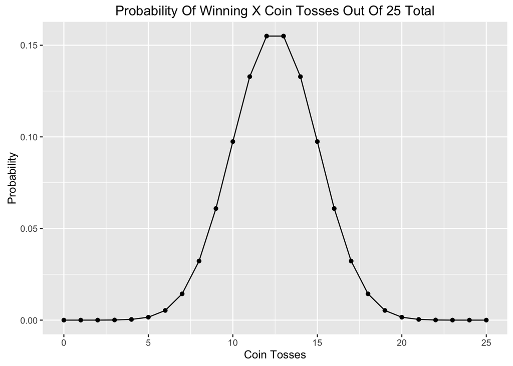

```r
ggplot(CoinFlips, aes(wins, probabilityXWins)) + geom_point() + geom_line() + labs((list(title = "Probability Of Winning X Coin Tosses Out Of 25 Total", x = "Coin Tosses", y = "Probability")))
```

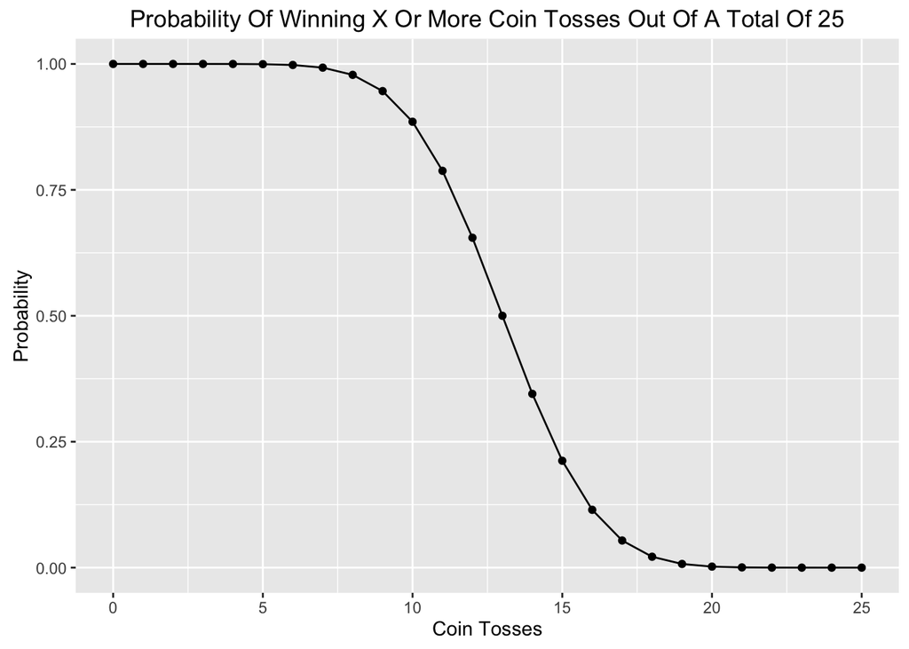

```r
ggplot(CoinFlips, aes(wins, probabilityXOrMoreWins)) + geom_point() + geom_line() + labs((list(title = "Probability Of Winning X Or More Coin Tosses Out Of A Total Of 25", x = "Coin Tosses", y = "Probability")))
```

Now to find the probability of finding fewer than X wins in 25 trials.

```r
CoinFlips<- cbind(CoinFlips, probabilityFewerThanXWins = pbinom(wins-1,totalFlips, probability))
head(CoinFlips)
```

```
##   wins probabilityXOrMoreWins probabilityXWins probabilityFewerThanXWins
## 1    0              1.0000000     2.980232e-08              0.000000e+00
## 2    1              1.0000000     7.450581e-07              2.980232e-08
## 3    2              0.9999992     8.940697e-06              7.748604e-07
## 4    3              0.9999903     6.854534e-05              9.715557e-06
## 5    4              0.9999217     3.769994e-04              7.826090e-05
## 6    5              0.9995447     1.583397e-03              4.552603e-04
```

And then plot.

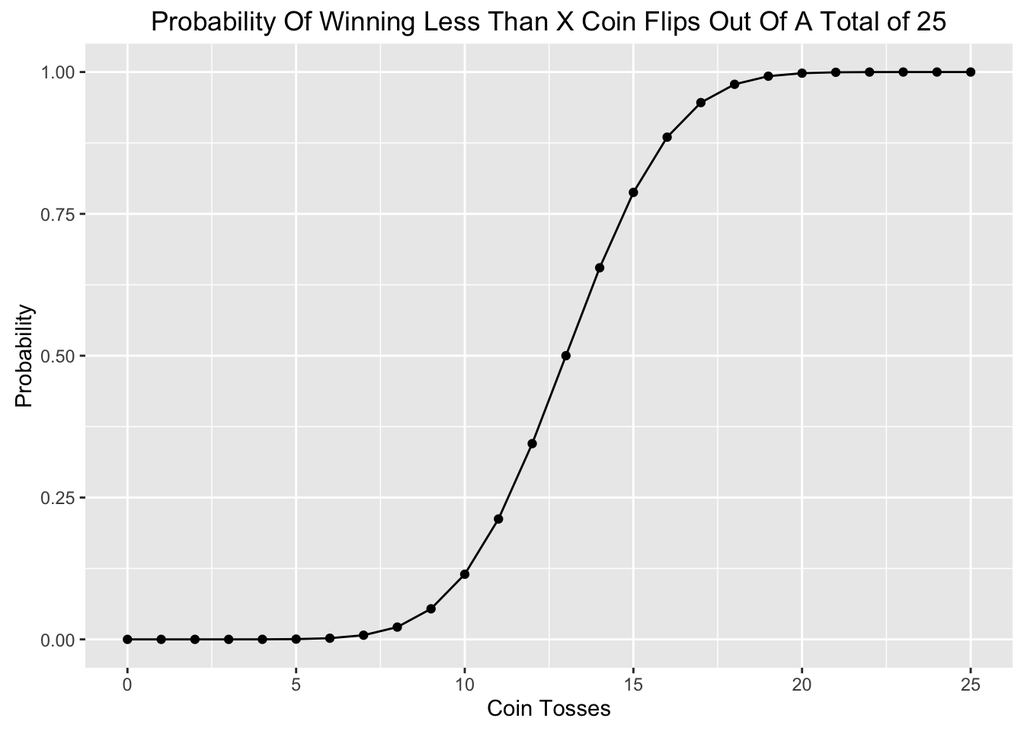

```r
ggplot(CoinFlips, aes(wins, probabilityFewerThanXWins)) + geom_point() + geom_line() + labs((list(title = "Probability Of Winning Less Than X Coin Flips Out Of A Total of 25", x = "Coin Tosses", y = "Probability")))
```

##### More articles on the Patriots and winning coin tosses:

http://blog.masslive.com/patriots/2015/11/will_patriots_win_the_coin_fli.html

http://harvardsportsanalysis.org/2015/11/nocbs/

http://www.patspulpit.com/2015/11/4/9672716/the-patriots-cheat-at-coin-flips-too

http://www.mathofpolitics.com/2016/01/25/the-patriots-are-commonly-uncommon/

https://meangreenmath.com/2016/02/07/new-england-patriots-cheat-at-the-pre-game-coin-flip-not-really/